# Connecting to a MySQL Database in Python

## Instructions

You must get this working on your local install of python! to do this you'll need to setup anaconda, install sqlalchemy and pymysql, you'll also need to configure your database, finally you'll need to import some data connect to a schema / database and execute a query.

output your notebook as html and turn it in.

## Requirements

Before proceeding, make sure you have the following Python packages installed:

- SQLAlchemy: A SQL toolkit and Object-Relational Mapping (ORM) library for Python.
- pymysql: A MySQL client library for Python.

```python
#!pip install sqlalchemy pymysql
```

```python
# import libs

import pandas as pd
import sqlalchemy as sa
import matplotlib.pyplot as plt
import seaborn as sns
from sqlalchemy import create_engine, text

# suppress warnings
import warnings
warnings.filterwarnings("ignore")


# charts inline
%matplotlib inline
```

## Connect to Database

Here's a Python code snippet for connecting to a MySQL database:

### Explanation

sa.create_engine(): This function creates a new SQLAlchemy engine, which represents the core interface to the database.

```
dialect+driver://username:password@host/dbname
```

- dialect: The database system you are using (e.g., mysql).
- driver: The database driver (e.g., pymysql for MySQL).
- username: The username to connect to the database.
- password: The password for the given username.
- host: The database server address.
- dbname: The name of the database aka schema you want to connect to.

```python
# Connection parameters
username = 'dbuser'
password = '123456'
host = 'localhost'
database = 'medicare'

try:
    # Create a database connection using SQLAlchemy
    engine = sa.create_engine(f'mysql+pymysql://{username}:{password}@{host}/{database}')
    print("Connected!")
except Exception as e:
    print(f"Not connected! Error: {e}")
```

```
Connected!
```

```python
#  define SQL as a string
query = """
select generic_name, sum(total_claim_count) tot_claims
from medicare.nc_scripts
where generic_name in (select distinct generic_name from medicare.opioid_list)
group by generic_name
order by 2 desc
limit 10
"""
# -- get result of SQL
res01 = pd.read_sql(query, engine)

res01
```

|  | generic_name | tot_claims |
| --- | --- | --- |
| 0 | HYDROCODONE/ACETAMINOPHEN | 173345.0 |
| 1 | OXYCODONE HCL/ACETAMINOPHEN | 103102.0 |
| 2 | TRAMADOL HCL | 96353.0 |
| 3 | OXYCODONE HCL | 76506.0 |
| 4 | MORPHINE SULFATE | 20941.0 |
| 5 | FENTANYL | 19558.0 |
| 6 | OXYMORPHONE HCL | 8088.0 |
| 7 | METHADONE HCL | 7231.0 |
| 8 | ACETAMINOPHEN WITH CODEINE | 5794.0 |
| 9 | HYDROMORPHONE HCL | 5308.0 |

## Make a plot

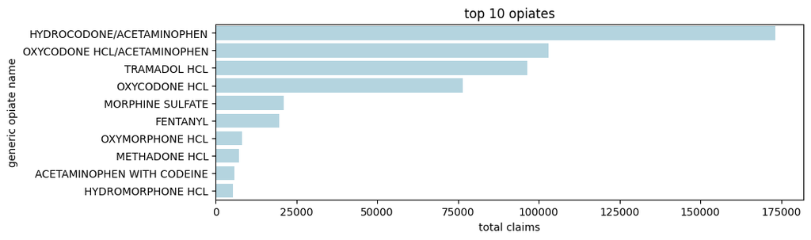

```python
plt.figure(figsize=(10,3))
sns.barplot(res01,y='generic_name', x='tot_claims', color='lightblue')
plt.title("top 10 opiates")
plt.xlabel("total claims")
plt.ylabel("generic opiate name")
plt.show()
```

## Disconnect from Database

To disconnect from the database using SQLAlchemy, use the `dispose()` method on the engine object. This will close the connection to the database.

```python
# # Close the database connection
# engine.dispose()
# print("Connection closed!")
```

# Task 1

using engine.connect() to execute query independently since it appears that the original method is unable to execute multiple queries at once.``

```python
with engine.connect() as connection:
    connection.execute(text("drop temporary table if exists top_opioid_cost;"))

    connection.execute(text("""
    create temporary table top_opioid_cost as
    select
        'opiate' as drug_type,
        drug_name,
        generic_name,
        avg(total_drug_cost / total_day_supply) as avg_daily_drug_cost
    from (
        select n.*
        from nc_scripts as n
        join opioid_list as o
        on n.drug_name = o.drug_name
    ) as opioid_script
    group by 1, 2, 3
    order by avg_daily_drug_cost desc
    limit 1;
    """))

    result = text("""
    with top_non_opioid_cost as (
        select
            'non opiate' as drug_type,
            drug_name,
            generic_name,
            avg(total_drug_cost / total_day_supply) as avg_daily_drug_cost
        from nc_scripts
        where drug_name not in (select drug_name from opioid_list)
        group by 1, 2, 3
        order by avg_daily_drug_cost desc
        limit 1
    )
    select * from top_opioid_cost
    union all
    select * from top_non_opioid_cost
    order by avg_daily_drug_cost desc;
    """)

    query_1 = pd.read_sql(result, connection)

print(query_1)
```

```
    drug_type drug_name           generic_name  avg_daily_drug_cost
0  non opiate   HARVONI  LEDIPASVIR/SOFOSBUVIR          1132.949154
1      opiate   FENTORA       FENTANYL CITRATE           409.368033
```

# Task 2

```python
query = """
with sum_total_day_supply as (
select
s.npi,
sum(s.total_day_supply) as sum_total_day_supply,
count(distinct(l.drug_name)) as distinct_drug_count
from nc_scripts s
join opioid_list l
on s.drug_name = l.drug_name
group by npi)

select
p.NPI,
concat(p.Last_Name, ',', p.First_Name) as last_name_first,
p.Credentials,
p.Provider_Type,
e.organization_legal_name,
e.primary_specialty,
p.City_Name,
s.sum_total_day_supply,
s.distinct_drug_count
from nc_physician as p
join nc_phys_education as e
on p.NPI = e.npi
join sum_total_day_supply as s
on p.NPI = s.npi
order by s.sum_total_day_supply desc
limit 10;

"""

query_2 = pd.read_sql(query, engine)

query_2
```

|  | NPI | last_name_first | Credentials | Provider_Type | organization_legal_name | primary_specialty | City_Name | sum_total_day_supply | distinct_drug_count |
| --- | --- | --- | --- | --- | --- | --- | --- | --- | --- |
| 0 | 1790758183 | BARTLETTE,ASHLEY | PA | Physician Assistant | EAST CAROLINA ANESTHESIA ASSOCIATES PLLC | PHYSICIAN ASSISTANT | HICKORY | 168161.0 | 16 |
| 1 | 1326033879 | BROCKMAN,STEVEN | MD | Anesthesiology | PAIN CLINIC OF SHELBY PC | PAIN MANAGEMENT | SHELBY | 135355.0 | 10 |
| 2 | 1568548345 | BRADFORD,ARTHUR | M.D. | Family Practice | BRIER CREEK INTEGRATED PAIN AND SPINE, PLLC | FAMILY PRACTICE | LUMBERTON | 114711.0 | 16 |
| 3 | 1376821561 | BURKE,TAMMY | NP | Nurse Practitioner | EAST CAROLINA ANESTHESIA ASSOCIATES PLLC | NURSE PRACTITIONER | STATESVILLE | 102577.0 | 15 |
| 4 | 1326081571 | CLAYTON,THOMAS | MD | Family Practice | ANDREWS INTERNAL MEDICINE PA | FAMILY PRACTICE | ANDREWS | 96861.0 | 19 |
| 5 | 1891792859 | BOTHE,BRIAN | MD | Physical Medicine and Rehabilitation | NA | PHYSICAL MEDICINE AND REHABILITATION | ARDEN | 76049.0 | 15 |
| 6 | 1730193665 | ARVIND,MOOGALI | M.D. | Internal Medicine | BETHANY MEDICAL CENTER | INTERNAL MEDICINE | HIGH POINT | 75859.0 | 14 |
| 7 | 1962488619 | ALVES,LEONILDE | PA-C | Physician Assistant | EMERGEORTHO, PA | PHYSICIAN ASSISTANT | DURHAM | 68999.0 | 15 |
| 8 | 1538176342 | BURNS,ANDREA | PA-C | Physician Assistant | ADVANCED MEDICAL GROUP | PHYSICIAN ASSISTANT | PINEHURST | 66959.0 | 12 |
| 9 | 1013139096 | CLARKE,JEFFREY | PA | Physician Assistant | COLUMBUS REGIONAL HEALTH NETWORK | PHYSICIAN ASSISTANT | WHITEVILLE | 61467.0 | 13 |

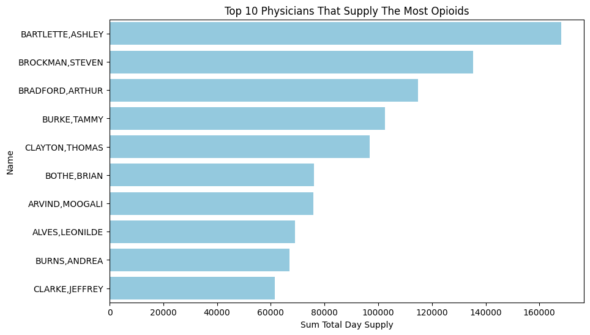

```python
plt.figure(figsize=(10, 6))
sns.barplot(
    data = query_2,
    x = 'sum_total_day_supply',
    y = 'last_name_first',
    color= 'skyblue'
)
plt.xlabel('Sum Total Day Supply')
plt.ylabel('Name')
plt.title('Top 10 Physicians That Supply The Most Opioids')
plt.show()
```

# Task 3

```python
query = """
select "nam's result" as "nam's result",
s.drug_name,
sum(total_claim_count) as total_claim_count
from nc_scripts s
join opioid_list l
on s.drug_name = l.drug_name
group by drug_name
order by total_claim_count desc
limit 10;
"""
result_3 = pd.read_sql(query, engine)

result_3
```

|  | nam's result | drug_name | total_claim_count |
| --- | --- | --- | --- |
| 0 | nam's result | HYDROCODONE-ACETAMINOPHEN | 173261.0 |
| 1 | nam's result | TRAMADOL HCL | 95877.0 |
| 2 | nam's result | OXYCODONE HCL | 63320.0 |
| 3 | nam's result | FENTANYL | 19346.0 |
| 4 | nam's result | MORPHINE SULFATE ER | 17445.0 |
| 5 | nam's result | OXYCONTIN | 12981.0 |
| 6 | nam's result | HYDROMORPHONE HCL | 9474.0 |
| 7 | nam's result | METHADONE HCL | 7231.0 |
| 8 | nam's result | ACETAMINOPHEN-CODEINE | 5783.0 |
| 9 | nam's result | OPANA ER | 5073.0 |

# Task 4

```python
query = """
select
drug_name,
sum(total_claim_count) as total_claim_count
from nc_scripts
where drug_name not in (select drug_name from opioid_list)
group by drug_name
order by sum(total_claim_count) desc
limit 10;
"""

result_4 = pd.read_sql(query, engine)

result_4
```

|  | drug_name | total_claim_count |
| --- | --- | --- |
| 0 | AMLODIPINE BESYLATE | 262995.0 |
| 1 | OMEPRAZOLE | 242374.0 |
| 2 | LISINOPRIL | 239434.0 |
| 3 | LEVOTHYROXINE SODIUM | 232523.0 |
| 4 | ATORVASTATIN CALCIUM | 230178.0 |
| 5 | FUROSEMIDE | 180870.0 |
| 6 | SIMVASTATIN | 174201.0 |
| 7 | GABAPENTIN | 162792.0 |
| 8 | METFORMIN HCL | 137929.0 |
| 9 | METOPROLOL SUCCINATE | 130949.0 |